# S2.1: la griglia dei quadratini di Visium HD sopra le cellule simulate è costruita bene, anche contro Space Ranger sui vetrini veri?

geo_spatialtrans, report di step (protocollo v2)

Published

November 5, 2026

# In breve

## In breve: la griglia dei quadratini di Visium HD sopra le cellule simulate è costruita bene, anche contro Space Ranger sui vetrini veri?

**A cosa serviva.** È il primo pezzo di codice dello Step 2. La funzione posa la griglia dei quadratini di 2 µm, e i blocchi di 8 µm, sopra le cellule dello Step 1. Per ogni quadratino calcola quanta parte cade in ogni cellula e in ogni nucleo. Questa «verità geometrica» servirà a mettere alla prova i metodi che assegnano i quadratini alle cellule. Se la griglia fosse numerata o posata male, ogni prova successiva sarebbe sbagliata senza che nessuno se ne accorga.

**Cosa abbiamo trovato.**

1. **Sui vetrini veri la nostra griglia coincide con quella di Space Ranger, quadratino per quadratino.**
   - Lo abbiamo controllato in 25 aree di cinque tessuti: tumore del colon, stroma del tumore, linfonodo, cervello di topo, cuore. A ogni nucleo di Space Ranger attribuiamo esattamente i quadratini che Space Ranger gli assegna, e nessun quadratino cade a metà di un nucleo.
   - Tre griglie sbagliate di proposito arrivano al più al 70 % di accordo: righe e colonne scambiate, righe al contrario, griglia spostata di mezzo quadratino. Il controllo distingue il giusto dallo sbagliato.
   - Il passo della griglia vale 2 µm entro un millesimo in tutti e cinque i vetrini, e i blocchi di 8 µm sono gli stessi di Space Ranger.
2. **Uno dei controlli automatici non è passato come lo avevo scritto: l’ipotesi sullo Step 1 era sbagliata, la griglia no.**
   - Avevo dato per scontato che i territori delle cellule coprissero tutto il tessuto. In 6 aree su 30, invece, lo Step 1 lascia piccole regioni di tessuto senza cellule. Sono pixel isolati nel cuore e nello stroma e una macchia di 560 µm² nel cervello: in tutto 632 µm² su 26 mm² di tessuto simulato.
   - Rifatto sulle sole regioni con cellule, lo stesso controllo torna in tutte e 30 le aree. La differenza è tutta lì, e un revisore indipendente lo ha confermato con codice suo.
   - Per ora quei quadratini contano come tessuto senza cellule.
3. **Tutti gli altri controlli passano: aree giuste fino al milionesimo di µm², risultati riproducibili, file di partenza intatti.**
   - Un revisore ha ricalcolato le aree in modo esatto in sei aree, una per tessuto. Gli scarti sono di pochi milionesimi di µm², quanto ci si aspetta dall’arrotondamento delle coordinate.
   - Rifatto tutto in un’altra cartella e con un numero diverso di processi, i file risultano identici.
   - I controlli hanno trovato un difetto vero e l’ho corretto. Alcuni numeri di quadratino erano scritti in forma decimale, e quelli tondi (200 000 diventava «2e+05») perdevano la corrispondenza con la tabella dei quadratini. Dopo la correzione ho rifatto tutto.
   - In tre punti la mia pre-registrazione era sbagliata. L’ho corretta prima di calcolare e senza toccare le tue soglie. Una delle griglie sbagliate non poteva fallire nel modo previsto. La corrispondenza fra immagine e griglia di Space Ranger non è esatta su tutto il vetrino (fino a quasi un pixel di scarto), quindi la stimo area per area. La tolleranza data al revisore era più stretta della precisione dello strumento: lo stesso errore dello step precedente.
4. **Alla scala dei quadratini, le cellule simulate somigliano a quelle vere quanto lo permette la densità dello Step 1.**
   - Contro il segmentatore dello Step 1, i quadratini con il centro in un nucleo vanno da tre quarti di quelli veri (stroma) a 1.2 volte (cervello). La differenza viene tutta dal numero di cellule per mm² dei preset, mentre la taglia dei nuclei coincide entro il 4 %. È la revisione della densità dei preset che hai già deciso di fare con i vuoti del tessuto.
   - Contati come li conta Space Ranger, i nuclei per quadratino di 8 µm sono 1.3 nel tumore simulato come in quello vero, e 3.0 contro 3.3 nel linfonodo.
   - Un revisore ha mostrato che il mio primo confronto contava i nuclei in due modi diversi nel simulato e in Space Ranger. L’ho corretto prima di scrivere queste righe.
5. **Per un’area di 1 mm² la griglia si calcola in circa un minuto, con al più 1.5 GB di memoria.**
   - Fra il 59 e il 73 % dei quadratini è vetro attorno al tessuto: sono i 280 µm di margine che servono alla coda di diffusione.

**Cosa devi decidere.**

1. **Chiudiamo lo step anche se il controllo sulla copertura del tessuto non è passato come era scritto? Consiglio di sì.**
   - La causa è un’ipotesi della mia pre-registrazione, non la griglia. Il controllo rifatto sulle regioni con cellule passa ovunque, e il revisore lo ha riprodotto.
   - Alternativa: tenere lo step aperto finché lo Step 1 non smette di produrre regioni senza cellule. Conseguenza: lavoro sullo Step 1 prima di andare avanti, senza alcun cambiamento nella griglia.

**Comunque**: che cosa fare dei pezzetti di tessuto senza cellule (toglierli o tenerli come tessuto vuoto) lo decideremo quando scriveremo la funzione che mette insieme tutto lo Step 2. La differenza di densità vista alla scala dei quadratini va alla revisione della densità dei preset. Come mi hai detto, il documento di progetto non passa più da Daniele. La prossima sessione propone i profili di espressione per cellula.

Appena decidi questo punto, lo step è chiuso.

**Sui tempi di calcolo.** Li ho misurati io su lesexp-server, con 5 processi miei mentre giravano anche le tue meta-analisi (carico medio fra 14 e 17 processi): 46-81 secondi per area di 1 mm², mediana 58. Vanno bene per dimensionare il lavoro, non per un manoscritto.

# Decisioni e verifiche di Luca

- «cosa devo mandare a Daniele? Intanto procedi» e «Griglia + controllo su Space Ranger + confronto descrittivo (Recommended)» (chat, 2026-11-05): perimetro dello step.
- «Ok, come proposte (Recommended)» (chat, 2026-11-05): ok sulla controprova e sul confronto descrittivo.
- «bypassiamo daniele, le decisioni vanno tutte bene il report è troppo tecnico per lui» (chat, 2026-11-05): il documento di progetto dello Step 2 non passa da Daniele prima del codice (DEC-042).
- «chiudi» (chat, 2026-11-05): risposta all’unica decisione del riassunto; lo step si chiude con il controllo sulla copertura del tessuto fallito come scritto (S2.1 chiusa con G-2 fallito come scritto (DEC-044)).

# Dubbi rinviati

| cosa | perché | cosa serve per chiuderlo | step destinatario | voce di BACKLOG |
| --- | --- | --- | --- | --- |
| regioni di tessuto senza cellule dello Step 1 (6 aree su 30, 632 µm²; pixel isolati e una regione di 560 µm² nel cervello): nella griglia sono tessuto senza territori | è una proprietà dello Step 1 con `min_region_area_um2 = 0`; cosa farne tocca la generazione dei trascritti | decidere nell’orchestratore se togliere dal tessuto le regioni senza cellule o tenerle come tessuto acellulare (limite D2-11 del documento di progetto); allineare la frase del documento sul riquadro d… | S2.5 | BL-212 |
| densità dei preset contro il segmentatore alla scala dei quadratini: rapporto 0.74 (stroma) … 1.24 (cervello), taglia dei nuclei entro il 4 % | non è della griglia: viene dai preset dello Step 1 | rivederla nello step della densità dei preset con i vuoti del tessuto (con BL-167) | da assegnare (con BL-167) | BL-213 |
| tempo e memoria su un’area di cattura intera: misurati solo per 1 mm² (circa 1 minuto, al più 1.5 GB) | l’area intera va a tessere con l’orchestratore | misura su un’area intera a tessere con tutti gli strati | S2.5 | BL-214 |

# Cancelli e controprova

Non ci sono previsioni con intervallo di rilevanza biologico (scelta di Luca sul perimetro): la griglia non ha parametri biologici. Esiti come pre-registrati, con le tre correzioni prima del calcolo.

| id | controllo | esito | numeri | fonte |
| --- | --- | --- | --- | --- |
| G-1 | batteria di test e mutanti | **PASS** | 21/21 test; 11/11 mutanti rilevati da un test fallito, 0 errori bloccanti | `R/testing/test_S2.1.R`; `results/S2.1/S2.1_mutants.csv` |
| G-2 | invarianti sulle 30 aree | **FAIL come scritto** (c): 24/30 aree; (a), (b), (d), (e) PASS 30/30 | rapporto errore/tolleranza: (a) 0.148, (d) 5.2e-4 (0.131 con i soli pezzi di bordo), (e) 0.114, coppie nucleo/territorio 0; (c) 6 aree con regioni senza cellule; PH-1 30/30 | `results/S2.1/S2.1_G2.csv`, `S2.1_PH1_G2c_cells_only.csv` |
| G-3 | riproducibilità con 3 processi invece di 5 | **PASS** | 35/35 file identici (30 verità geometriche, 5 tabelle) | `/mnt/micron/geo_spatialtrans/S2.1/repro.log` |
| G-4 | integrità | **PASS** | 133 + 40 file con md5 identici; `results/R2`, `R3`, `S1.6` invariati | `/mnt/micron/geo_spatialtrans/S2.1/md5_after.log` |
| G-5 | revisione avversariale | **PASS** (ricalcolo che torna) | aree esatte a 2.29e-6 µm² (0.24 della tolleranza); CP-1 in 5 aree: numeri che decidono identici (accordo 1, 0 quadratini a metà, stessi insiemi di quadratini), numero di coppie diverso di 0-8 schegge … | `/mnt/micron/geo_spatialtrans/S2.1/review/` |
| CP-1 | griglia contro Space Ranger, 25 aree | **confermata** | CP-1a: quadratini a metà 0 in 25/25; CP-1b: accordo 1.000000 in 25/25; CP-1c: griglie sbagliate al più 0.7001, CP-1a fallisce con lo spostamento di mezzo quadratino; passo 1.99909-2.00043 µm; blocchi … | `results/S2.1/S2.1_CP1_roi.csv`, `S2.1_CP1_grid.csv` |

Righe dei log: S2.1 test: 21 PASS, 0 FAIL; mutanti rilevati da un FAIL (i crash non contano): 11/11; crash: 0; FAIL G-2 invarianti sulle 30 aree: 24/30 aree PASS; rapporti errore/tolleranza max a 0.148 c 499999.938 d 0.001 e 0.114; PH-1 G-2 (c) con le sole regioni con cellule: 30/30 aree entro la tolleranza (rapporto max 0.000); regioni senza cellule in 6 aree, area totale 632.1 um2; PASS G-3 riproducibilita’: 35 file identici (30 verita’ geometriche e 5 tabelle); PASS G-4 md5 identici prima e dopo; PASS G-4 results/R2, R3, S1.6 invariati rispetto al commit; 40 file in /mnt/micron/geo_spatialtrans/S2.1/md5_after_extra.txt; PASS G-4 md5 dei nuclei del descrittivo identici.

## Invarianti per area (G-2) e regioni senza cellule (PH-1)

Rapporto errore/tolleranza (≤ 1 = entro la tolleranza a n pezzi di DEC-038). (c) fallisce come scritto solo dove ci sono regioni senza cellule.

| area | tessuto | cellule | (a) | (c) come scritto | (c) solo regioni con cellule | (d) | (d) solo bordo | (e) | regioni senza cellule | area senza cellule (µm²) |
| --- | --- | --- | --- | --- | --- | --- | --- | --- | --- | --- |
| A1_r1 | intestino di topo | 9914 | 0.148 | 7.63e-11 | 7.6e-11 | 9.7e-05 | 0.003 | 0.104 | 0 | 0.0 |
| A1_r2 | intestino di topo | 8475 | 0.114 | 5.95e-11 | 5.9e-11 | 0.00014 | 0.003 | 0.104 | 0 | 0.0 |
| A1_r3 | intestino di topo | 10061 | 0.110 | 5.53e-11 | 5.5e-11 | 0.00011 | 0.004 | 0.095 | 0 | 0.0 |
| A1_r4 | intestino di topo | 7933 | 0.131 | 5.49e-11 | 5.5e-11 | 0.00016 | 0.004 | 0.101 | 0 | 0.0 |
| A1_r5 | intestino di topo | 8981 | 0.135 | 6.08e-11 | 6.1e-11 | 0.00022 | 0.006 | 0.108 | 0 | 0.0 |
| A2_r1 | tumore del colon | 6642 | 0.091 | 5.9e-11 | 5.9e-11 | 0.00029 | 0.010 | 0.093 | 0 | 0.0 |
| A2_r2 | tumore del colon | 7689 | 0.091 | 5.3e-11 | 5.3e-11 | 0.00023 | 0.016 | 0.111 | 0 | 0.0 |
| A2_r3 | tumore del colon | 6110 | 0.089 | 5.42e-11 | 5.4e-11 | 0.00032 | 0.013 | 0.105 | 0 | 0.0 |
| A2_r4 | tumore del colon | 8666 | 0.103 | 5.1e-11 | 5.1e-11 | 0.0003 | 0.034 | 0.101 | 0 | 0.0 |
| A2_r5 | tumore del colon | 8701 | 0.087 | 5.28e-11 | 5.3e-11 | 0.00028 | 0.047 | 0.114 | 0 | 0.0 |
| A3_r1 | stroma del tumore | 3089 | 0.070 | 5.23e-11 | 5.2e-11 | 0.00029 | 0.093 | 0.102 | 0 | 0.0 |
| A3_r2 | stroma del tumore | 3074 | 0.057 | 1.89e+05 | 5.5e-11 | 0.0003 | 0.073 | 0.109 | 2 | 2.4 |
| A3_r3 | stroma del tumore | 3099 | 0.071 | 5.26e-11 | 5.3e-11 | 0.0003 | 0.131 | 0.112 | 0 | 0.0 |
| A3_r4 | stroma del tumore | 3093 | 0.073 | 5.45e-11 | 5.4e-11 | 0.0003 | 0.104 | 0.099 | 0 | 0.0 |
| A3_r5 | stroma del tumore | 3074 | 0.059 | 5.08e-11 | 5.1e-11 | 0.00029 | 0.081 | 0.101 | 0 | 0.0 |
| A4_f1 | linfonodo | 27834 | 0.122 | 5.3e-11 | 5.3e-11 | 0.00017 | 0.037 | 0.092 | 0 | 0.0 |
| A4_f2 | linfonodo | 28015 | 0.121 | 5.46e-11 | 5.5e-11 | 0.0002 | 0.061 | 0.106 | 0 | 0.0 |
| A4_p1 | linfonodo | 28075 | 0.120 | 5.34e-11 | 5.3e-11 | 0.00021 | 0.082 | 0.097 | 0 | 0.0 |
| A4_p2 | linfonodo | 27966 | 0.132 | 5.27e-11 | 5.3e-11 | 0.00021 | 0.065 | 0.094 | 0 | 0.0 |
| A4_p3 | linfonodo | 28101 | 0.132 | 5.17e-11 | 5.2e-11 | 0.0002 | 0.097 | 0.101 | 0 | 0.0 |
| A5_r1 | cervello di topo | 883 | 0.031 | 5e+05 | 8.2e-11 | 1.2e-05 | 0.000 | 0.109 | 1 | 560.2 |
| A5_r2 | cervello di topo | 996 | 0.027 | 5.42e-11 | 5.4e-11 | 2.9e-06 | 0.000 | 0.108 | 0 | 0.0 |
| A5_r3 | cervello di topo | 925 | 0.032 | 5.5e-11 | 5.5e-11 | 6.3e-05 | 0.001 | 0.108 | 0 | 0.0 |
| A5_r4 | cervello di topo | 888 | 0.034 | 5.44e-11 | 5.4e-11 | 2.9e-05 | 0.001 | 0.098 | 0 | 0.0 |
| A5_r5 | cervello di topo | 1030 | 0.035 | 5.12e-11 | 5.1e-11 | 1e-06 | 0.000 | 0.093 | 0 | 0.0 |
| A6_r1 | cuore | 912 | 0.046 | 3.54e+05 | 7.1e-11 | 0.00047 | 0.014 | 0.096 | 5 | 7.2 |
| A6_r2 | cuore | 889 | 0.093 | 3.29e+05 | 6e-11 | 0.00042 | 0.010 | 0.105 | 2 | 9.6 |
| A6_r3 | cuore | 955 | 0.032 | 5.04e-11 | 5e-11 | 0.00048 | 0.035 | 0.103 | 0 | 0.0 |
| A6_r4 | cuore | 921 | 0.057 | 2.74e+05 | 5.1e-11 | 0.0005 | 0.030 | 0.093 | 4 | 4.8 |
| A6_r5 | cuore | 898 | 0.035 | 5e+05 | 5.5e-11 | 0.00052 | 0.018 | 0.099 | 6 | 48.0 |

## Controprova CP-1: la nostra griglia contro Space Ranger

Per tessuto e griglia; scarto dell’affine per area come distanza.

| tessuto | griglia | aree | accordo min | accordo max | quota a metà max | scarto affine max (px) |
| --- | --- | --- | --- | --- | --- | --- |
| cervello di topo | nostra griglia | 5 | 1.0000 | 1.0000 | 0.0000 | 0.007 |
| cervello di topo | righe e colonne scambiate | 5 | 0.0000 | 0.0000 | 0.0000 | 0.007 |
| cervello di topo | mezzo quadratino | 5 | 0.6859 | 0.7001 | 0.6588 | 0.007 |
| cervello di topo | righe al contrario | 5 | 0.0000 | 0.0000 | 0.0000 | 0.007 |
| cuore | nostra griglia | 5 | 1.0000 | 1.0000 | 0.0000 | 0.001 |
| cuore | righe e colonne scambiate | 5 | 0.0000 | 0.0027 | 0.0000 | 0.001 |
| cuore | mezzo quadratino | 5 | 0.4284 | 0.5322 | 0.9062 | 0.001 |
| cuore | righe al contrario | 5 | 0.0000 | 0.0012 | 0.0000 | 0.001 |
| linfonodo | nostra griglia | 5 | 1.0000 | 1.0000 | 0.0000 | 0.031 |
| linfonodo | righe e colonne scambiate | 5 | 0.0000 | 0.0015 | 0.0000 | 0.031 |
| linfonodo | mezzo quadratino | 5 | 0.4400 | 0.4602 | 0.9004 | 0.031 |
| linfonodo | righe al contrario | 5 | 0.0000 | 0.0000 | 0.0000 | 0.031 |
| stroma del tumore | nostra griglia | 5 | 1.0000 | 1.0000 | 0.0000 | 0.033 |
| stroma del tumore | righe e colonne scambiate | 5 | 0.0000 | 0.0019 | 0.0000 | 0.033 |
| stroma del tumore | mezzo quadratino | 5 | 0.5094 | 0.5609 | 0.8555 | 0.033 |
| stroma del tumore | righe al contrario | 5 | 0.0000 | 0.0000 | 0.0000 | 0.033 |
| tumore del colon | nostra griglia | 5 | 1.0000 | 1.0000 | 0.0000 | 0.033 |
| tumore del colon | righe e colonne scambiate | 5 | 0.0000 | 0.0029 | 0.0000 | 0.033 |
| tumore del colon | mezzo quadratino | 5 | 0.5319 | 0.5551 | 0.8320 | 0.033 |
| tumore del colon | righe al contrario | 5 | 0.0000 | 0.0000 | 0.0000 | 0.033 |

Controlli per sezione. Lo scarto dell’affine sull’intera sezione, giudicato come scritto (< 0.5 pixel), fallisce nel tumore del colon e nel linfonodo: per questo CP-1 usa una trasformazione per area (correzione 2).

| sezione | passo (µm) | scarto affine sezione (px, componente) | come distanza | blocchi diversi | blocchi incompleti | di cui ultima riga/colonna | scarto centri 8 µm (px) |
| --- | --- | --- | --- | --- | --- | --- | --- |
| Visium_HD_Mouse_Small_Intestine | 1.99949 | 0.40 | 0.56 | NA | 1675 | 1675 | 0.0005 |
| Visium_HD_Human_Colon_Cancer | 1.99909 | 0.95 | 1.23 | 0 | 1675 | 1675 | 0.0038 |
| Visium_HD_Human_Lymph_Node_FFPE | 1.99996 | 0.82 | 1.15 | 0 | 1675 | 1675 | 0.0035 |
| Visium_HD_6p5mm_Mouse_Brain | 1.99976 | 0.18 | 0.25 | 0 | 1675 | 1675 | 0.0008 |
| Visium_HD_6p5mm_Human_Heart | 2.00043 | 0.02 | 0.03 | 0 | 1675 | 1675 | 0.0001 |

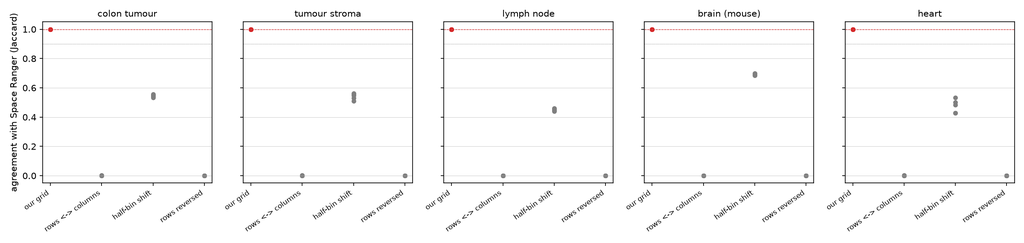

Accordo con Space Ranger per area e per griglia. Cosa guardare: solo la nostra griglia arriva a 1; le griglie sbagliate stanno sotto la linea di 0.9.

## Correzioni prima del calcolo, post hoc e deviazioni

Commit dei cancelli: `08f75d2`. Ok di Luca sulla controprova (soglie 1/1000 di quadratini a metà, accordo ≥ 0.999 per area, griglie sbagliate sotto 0.9) e sul confronto descrittivo senza soglie: 2026-11-05, «Ok, come proposte (Recommended)». Commit: vedi `git log` (S2.1: ok di Luca).

Nessuna casualità nella griglia: i risultati non dipendono da un seme. Seme del bootstrap = 20261105; B = 2000 (percentile 2.5-97.5); unità indipendente = area (5 per tessuto). Processi: al più 6 (il server è condiviso con le meta-analisi di Luca fino al 2026-11-06 alle 3:30). Uscite in `/mnt/micron/geo_spatialtrans/S2.1/run1` (un file per area, rilanciabile); tabelle in `results/S2.1/`.

Tolleranza geometrica (τ): per un insieme di n pezzi con perimetri P_k, τ = g · Σ P_k + n · g², g = 1e-6 µm; per le frazioni τ / 4 µm².

### Cancelli (al massimo 5)

| id | controllo | tolleranza | comando |
| --- | --- | --- | --- |
| G-1 | **batteria di test** su casi costruiti: (a) casi analitici: quadrato allineato alla griglia (frazioni esattamente 0 o 1), quadrato spostato di 0.5 µm in x e 1 µm in y (aree prodotto di 1.5, 2, 0.5 per… | aree entro τ; frazioni analitiche entro τ / 4; somme intere esatte; invarianze entro τ; PASS/FAIL per asserzione, tutti PASS | `R_LIBS_SITE=/nonexistent R_LIBS_USER=/nonexistent Rscript --vanilla R/testing/test_S2.1.R` |
| G-2 | **invarianti sulle 30 aree simulate** (tutte, 6 tessuti): (a) per ogni cellula, la somma delle aree sui quadratini = area del territorio e del nucleo in `cell_df`; (b) ogni cellula ha almeno un quadra… | (a), (c), (d), (e) entro τ dell’insieme di pezzi coinvolto; (b) 0 eccezioni | `Rscript --vanilla tools/S2.1_panel.R check` |
| G-3 | **riproducibilità**: seconda esecuzione completa (pannello e controprova) in un’altra cartella, con un numero di processi diverso | tabelle di risultato e verità geometriche con md5 identici | `tools/S2.1_repro.sh` |
| G-4 | **integrità**: md5 di ogni file letto (30 livelli cellulari di S1.6; per le 4 sezioni con Space Ranger 4: `barcode_mappings.parquet`, `nucleus_segmentations.geojson`, `cell_segmentations.geojson`, `ti… | identità | `tools/S2.1_md5.sh before / after` |
| G-5 | **revisione avversariale**: sotto-agenti con codice proprio (Python, shapely, senza le funzioni del pacchetto) ricalcolano (a) la verità geometrica di almeno un’area per tessuto; (b) la controprova su… | aree a 1e-9 µm² per coppia; conteggi identici; ogni discrepanza è un dubbio | sotto-agenti, report |

### Previsioni

Nessuna previsione con intervallo di rilevanza biologico: la griglia non ha parametri biologici, e il confronto simulato contro vero dipende dalla densità e dalla taglia dello Step 1, già giudicate allora (scelta di Luca sul perimetro, 2026-11-05). Il confronto resta descrittivo (D-1…D-3).

### Controprova

**CP-1, la nostra griglia contro quella di Space Ranger sui vetrini veri.** Le sezioni con Space Ranger 4 (tumore del colon, che contiene anche le aree dello stroma; linfonodo; cervello; cuore) hanno i nuclei segmentati da Space Ranger come poligoni tracciati lungo i lati dei quadratini di 2 µm (`nucleus_segmentations.geojson`, in pixel dell’immagine). Space Ranger assegna un quadratino a un nucleo se il suo centro cade sotto il nucleo[^sr_metrics] e scrive l’assegnazione in `barcode_mappings.parquet`[^sr_outputs].

Procedura per area (25 aree: 5 per tessuto in tumore, stroma, linfonodo, cervello, cuore):

1. si stima la trasformazione affine dai centri dei quadratini di 2 µm della sezione (pixel di `tissue_positions.parquet`) ai centri della nostra convenzione, (2 j + 1, 2 i + 1) µm con i = `array_row`, j = `array_col` (minimi quadrati su tutti i quadratini della sezione; riflessioni ammesse);
2. si portano nelle coordinate della griglia i nuclei di Space Ranger che cadono nell’area, e si calcola `truth$overlap` con `build_hd_grid()` (i nuclei fanno da territorio e da nucleo);
3. si confronta, quadratino per quadratino, con `in_nucleus` e `cell_id` di Space Ranger (corrispondenza fra il `cell_id` del poligono e quello di `barcode_mappings`, stabilita nell’esplorazione E-1).

Se la griglia e il calcolo sono giusti, i poligoni di Space Ranger sono unioni di nostri quadratini, quindi:

- **CP-1a**: le frazioni di nucleo dei quadratini toccati stanno fuori da [0.1, 0.9] (un quadratino è tutto dentro o tutto fuori), in almeno il 99.9 % delle coppie di ogni area;
- **CP-1b**: l’insieme dei quadratini con frazione ≥ 0.5 per un nucleo coincide con quello che Space Ranger assegna allo stesso nucleo; accordo (Jaccard sui quadratini del nucleo, sommato sull’area) ≥ 0.999 in ogni area;
- **CP-1c**, la parte che smentirebbe: con la griglia sbagliata di proposito (i e j scambiati; centri spostati di mezzo quadratino; righe numerate al contrario) l’accordo di CP-1b scende sotto 0.9 e CP-1a fallisce. Se una griglia sbagliata passasse, la controprova non avrebbe potere.

Inoltre, nelle 5 sezioni (anche l’intestino, che ha le posizioni dei quadratini): il blocco di 8 µm (⌊i/4⌋, ⌊j/4⌋) coincide con `square_008um` di `barcode_mappings` (4 sezioni) e con la media dei centri dei 16 figli in `tissue_positions` a 8 µm (5 sezioni); il passo della griglia, dalla trasformazione affine per la scala `microns_per_pixel`, vale 2 µm entro lo 0.5 %; scarto massimo dei centri dalla trasformazione sotto 0.5 pixel.

Esito: confermata se valgono CP-1a, CP-1b in tutte le 25 aree, CP-1c per tutte e tre le griglie sbagliate e i controlli dei blocchi; altrimenti smentita, con l’elenco delle aree e dei quadratini che non tornano. Il cuore qui non è un controllo negativo: la griglia non dipende dalla forma delle cellule.

### Correzioni prima del calcolo (dichiarate, commit separato, nessun calcolo della controprova eseguito prima)

1. **CP-1c, griglie sbagliate e quadratini a metà** (2026-11-05, scritta mentre preparavo il codice della controprova, prima di eseguirlo). La pre-registrazione chiedeva che con ciascuna delle tre griglie sbagliate fallisse anche CP-1a (quadratini a metà). Con righe e colonne scambiate, o con le righe numerate al contrario, la griglia resta allineata ai lati dei quadratini: i nuclei di Space Ranger restano unioni di quadratini interi e CP-1a non può fallire per costruzione. Solo la griglia spostata di mezzo quadratino rompe l’allineamento. Criterio corretto: con tutte e tre le griglie sbagliate l’accordo di CP-1b scende sotto 0.9; CP-1a fallisce con la griglia spostata di mezzo quadratino. Le soglie approvate da Luca non cambiano.
2. **CP-1, una trasformazione per area invece di una per sezione** (2026-11-05, dopo l’esplorazione E-1 e prima di calcolare CP-1). E-1 sul tumore del colon: gli id del geojson corrispondono a `cellid_<9 cifre>-1` di `barcode_mappings` (2 000 su 2 000); `array_row` cresce verso l’alto dell’immagine (riflessione, ammessa); passo 7.3039 pixel = 1.99909 µm; ma la trasformazione affine sull’intera sezione lascia uno scarto massimo di 0.2598 µm (0.95 pixel), sopra il limite di 0.5 pixel scritto nella pre-registrazione. La corrispondenza fra immagine e griglia di Space Ranger non è affine su 6.5 mm; uno scarto di 0.2 µm su un lato basta a portare un quadratino «a metà» (frazione 0.9) senza alcun difetto della nostra griglia. Correzione: la trasformazione si stima per area, sui quadratini del riquadro dell’area allargato di 200 pixel; il limite di 0.5 pixel vale per le trasformazioni per area. Lo scarto della trasformazione per sezione si riporta e si giudica come scritto (in E-1 fallisce). Le soglie approvate da Luca non cambiano.
3. **G-5 (a), tolleranza del ricalcolo indipendente delle aree** (2026-11-05, prima di avviare la revisione avversariale). La pre-registrazione chiedeva aree uguali a 1e-9 µm² per coppia. `overlay_prec()` arrotonda le coordinate a g = 1e-6 µm, quindi un ricalcolo esatto (per esempio shapely senza arrotondamento) differisce per costruzione fino a circa g · P per pezzo (P ≤ 8 µm per un quadratino di un poligono convesso: alcuni milionesimi di µm²). Il limite di 1e-9 era più stretto della precisione dichiarata dello strumento: è lo stesso tipo di errore della revisione dei bordi in S2.0. Correzione: per coppia, |scarto| ≤ τ dei due pezzi (g · (P_nostro + P_revisore) + 2 g², la regola di DEC-038 punto 4, la stessa di G-1 e G-2). I conteggi (D-1…D-3, CP-1) restano «identici».

### Riferimenti descrittivi (senza previsione)

Per tessuto, media delle 5 aree con intervallo bootstrap delle aree; quadratini «in tessuto» definiti allo stesso modo per simulato e vero: `in_tissue` della nostra griglia sulle regioni del livello cellulare della stessa area.

- **D-1** frazione dei quadratini di 2 µm in tessuto il cui centro cade in un nucleo: simulato (U6); vero con i nuclei di Space Ranger (4 sezioni) e con i nuclei del segmentatore di R2b usati nello Step 1 (nuclei di R3, 6 tessuti).
- **D-2** numero di nuclei distinti che toccano un quadratino di 8 µm in tessuto (distribuzione 0, 1, 2, 3, ≥ 4 e media): stesse tre fonti.
- **D-3** numero di cellule distinte per quadratino di 8 µm in tessuto e frazione di quadratini di 2 µm «puri» (un solo territorio ≥ 99 % dell’area di tessuto): simulato; vero con le cellule espanse di Space Ranger (`cell_segmentations.geojson`, cellule distinte per quadratino di 8 µm) dichiarando che le cellule di Space Ranger non coprono tutto il tessuto.
- **D-4** tempo e memoria di `build_hd_grid()` per area di 1 mm² (con il carico del server al momento della misura; non entra in un manoscritto).
- **PH-1, G-2 (c) sulle sole regioni con cellule** (`tools/S2.1_panel.R ph1`, `results/S2.1/S2.1_PH1_G2c_cells_only.csv`). G-2 (c) è fallito come scritto in 6 aree su 30 (A3_r2, A5_r1, A6_r1, A6_r2, A6_r4, A6_r5): lo Step 1 lascia regioni senza cellule (pixel isolati di 1.2 µm² nel cuore e nello stroma, una regione di 560.2 µm² in A5_r1; 632.1 µm² in tutto su 26.46 mm² di tessuto simulato), che sono tessuto ma non hanno territori. Rifatto con l’area di tessuto delle sole regioni con cellule, il controllo passa in 30 aree su 30 (rapporto errore/tolleranza massimo 8.2e-11). Confermato dal revisore della geometria con codice proprio (185/185 e 17/17 quadratini spiegati in A5_r1 e A6_r1).
- **PH-2, densità e area dei nuclei** (`tools/S2.1_ph2.R`, `results/S2.1/S2.1_PH2_density_area.csv`). Le differenze di D-1 fra simulato e segmentatore dello Step 1 vengono dalla densità dei preset: rapporto simulato/segmentatore dei nuclei per mm² 0.743 (stroma) … 1.243 (cervello), dell’area media del nucleo 0.963-1.035; correlazione fra rapporto di D-1 e rapporto della copertura nucleare 1.000 sulle 30 aree. Nessun effetto proprio della griglia; il tema è la revisione della densità dei preset (BL-167, DEC-033 punto 7).

### Deviazioni dichiarate

1. **Difetto trovato da G-2 e corretto** (prima esecuzione, cartella `run0_bindid`): `bin_id` della verità geometrica era in virgola mobile; nei raggruppamenti per nome i quadratini con numeri tondi (per esempio 200000, scritto «2e+05») perdevano la corrispondenza con la tabella dei quadratini (intero). Indici resi interi nel pacchetto, test T-B6 aggiunto, tutto rifatto.
2. **Correzioni dalla revisione avversariale** (cartella `run0b_prereview` per il calcolo prima delle correzioni; tutto rifatto in `run1` e riprodotto in `run2`): descrittivi D-2 e D-3 con la regola del centro (un nucleo o una cellula conta in un blocco di 8 µm se contiene il centro di almeno uno dei 16 figli: è la regola con cui Space Ranger costruisce i suoi nuclei) per il confronto con Space Ranger, e con la regola del tocco (area > 0; nei dati veri: pixel il cui centro cade in un figlio, non più 7 × 7 punti) per il confronto con il segmentatore; memoria come picco residente del processo; G-2 (d) riportato anche con la tolleranza dei soli pezzi di bordo; scarto dell’affine anche come distanza; intervallo chiuso [0.1, 0.9] in CP-1a; test e mutanti più forti (vedi «Revisione avversariale»); controlli dei casi limite in `build_hd_grid()`; colonne esplicite in `sum_to_8um()`.
3. **Testo corretto rispetto al codice** (revisione F02, F12, F13): CP-1 chiama `hd_overlap()` su una griglia allineata a quella di Space Ranger, non `build_hd_grid()`: verifica l’intersezione fra quadratini e poligoni e la numerazione di righe e colonne, mentre l’origine, i centri e il margine della griglia simulata sono coperti da G-1 (T-B1, T-B2) e da G-2 (b). Nei dati veri «in tessuto» è la maschera dello Step 1 letta al centro del quadratino (sul simulato le due regole differiscono per 28-1 238 quadratini su circa 2e5, D-1 al più 2e-4). D-3 di Space Ranger usa `cell_id` di `barcode_mappings` (cellule espanse), non `cell_segmentations.geojson` (letto solo per l’md5). I nuclei del segmentatore sono Cellpose RGB di R2 (intestino, tumore, stroma, cervello) e il consenso di R3b (linfonodo, cuore), con il filtro `keep` come R4.
4. **G-2 (e)** confronta la somma a 8 µm con la verità calcolata con la stessa `hd_overlap()` sui quadrati di 8 µm: prova la somma, non la geometria; la geometria è coperta da T-A3 (ritaglio indipendente) e dal ricalcolo esatto di G-5 (a).
5. **Due griglie sbagliate di CP-1c** (righe e colonne scambiate, righe al contrario) controllano solo la numerazione: l’affine stimata sui bersagli sbagliati assorbe l’errore nella geometria. La geometria la controlla la griglia spostata di mezzo quadratino (revisione F5).
6. **I tempi** (D-4) sono misurati con il server condiviso (carico medio 13.7-16.6 processi durante la misura) e comprendono il margine di vetro (fra il 59 e il 73 % dei quadratini di un’area): non entrano in un manoscritto.

# Descrittivi: simulato contro vero alla scala dei quadratini

Media delle 5 aree per tessuto, intervallo bootstrap delle aree (B = 2000, seme 20261105). Regola del centro: nucleo o cellula che contiene il centro di almeno uno dei 16 figli; regola del tocco: area > 0.

| archetype | label | simulated | segmenter (Step 1) | Space Ranger 4 |
| --- | --- | --- | --- | --- |
| cervello di topo | 2 um bins in tissue with centre in a nucleus | 0.107 [0.106, 0.109] | 0.091 [0.079, 0.107] | 0.056 [0.039, 0.075] |
| cuore | 2 um bins in tissue with centre in a nucleus | 0.024 [0.024, 0.024] | 0.025 [0.023, 0.027] | 0.026 [0.024, 0.029] |
| intestino di topo | 2 um bins in tissue with centre in a nucleus | 0.180 [0.179, 0.181] | 0.155 [0.150, 0.160] | NA |
| linfonodo | 2 um bins in tissue with centre in a nucleus | 0.472 [0.472, 0.473] | 0.451 [0.425, 0.475] | 0.575 [0.537, 0.609] |
| stroma del tumore | 2 um bins in tissue with centre in a nucleus | 0.112 [0.111, 0.113] | 0.154 [0.127, 0.173] | 0.152 [0.128, 0.172] |
| tumore del colon | 2 um bins in tissue with centre in a nucleus | 0.309 [0.307, 0.311] | 0.280 [0.264, 0.294] | 0.298 [0.256, 0.344] |
| cervello di topo | 2 um bins inside one territory (>= 99 %) | 0.867 [0.864, 0.871] | NA | NA |
| cuore | 2 um bins inside one territory (>= 99 %) | 0.872 [0.870, 0.875] | NA | NA |
| intestino di topo | 2 um bins inside one territory (>= 99 %) | 0.577 [0.576, 0.579] | NA | NA |
| linfonodo | 2 um bins inside one territory (>= 99 %) | 0.395 [0.395, 0.395] | NA | NA |
| stroma del tumore | 2 um bins inside one territory (>= 99 %) | 0.769 [0.769, 0.770] | NA | NA |
| tumore del colon | 2 um bins inside one territory (>= 99 %) | 0.628 [0.625, 0.631] | NA | NA |
| cervello di topo | cells per 8 um bin, centre rule (mean) | 1.464 [1.440, 1.486] | NA | 0.503 [0.354, 0.666] |
| cuore | cells per 8 um bin, centre rule (mean) | 1.460 [1.447, 1.473] | NA | 0.563 [0.482, 0.633] |
| intestino di topo | cells per 8 um bin, centre rule (mean) | 2.859 [2.840, 2.879] | NA | NA |
| linfonodo | cells per 8 um bin, centre rule (mean) | 4.336 [4.327, 4.346] | NA | 4.338 [4.113, 4.547] |
| stroma del tumore | cells per 8 um bin, centre rule (mean) | 1.924 [1.921, 1.926] | NA | 1.661 [1.531, 1.785] |
| tumore del colon | cells per 8 um bin, centre rule (mean) | 2.617 [2.583, 2.652] | NA | 2.385 [2.170, 2.595] |
| cervello di topo | nuclei per 8 um bin, centre rule (mean) | 0.271 [0.266, 0.275] | 0.235 [0.198, 0.278] | 0.157 [0.108, 0.206] |
| cuore | nuclei per 8 um bin, centre rule (mean) | 0.117 [0.115, 0.118] | 0.128 [0.112, 0.143] | 0.132 [0.118, 0.147] |
| intestino di topo | nuclei per 8 um bin, centre rule (mean) | 1.144 [1.135, 1.153] | 1.012 [0.990, 1.029] | NA |
| linfonodo | nuclei per 8 um bin, centre rule (mean) | 2.976 [2.972, 2.981] | 2.934 [2.690, 3.155] | 3.260 [2.983, 3.514] |
| stroma del tumore | nuclei per 8 um bin, centre rule (mean) | 0.460 [0.458, 0.461] | 0.668 [0.565, 0.739] | 0.678 [0.581, 0.757] |
| tumore del colon | nuclei per 8 um bin, centre rule (mean) | 1.277 [1.257, 1.297] | 1.173 [1.103, 1.229] | 1.277 [1.095, 1.474] |
| cervello di topo | nuclei per 8 um bin, touch rule (mean) | 0.347 [0.342, 0.352] | 0.292 [0.245, 0.354] | NA |
| cuore | nuclei per 8 um bin, touch rule (mean) | 0.165 [0.162, 0.167] | 0.170 [0.148, 0.192] | NA |
| intestino di topo | nuclei per 8 um bin, touch rule (mean) | 1.690 [1.679, 1.700] | 1.445 [1.411, 1.471] | NA |
| linfonodo | nuclei per 8 um bin, touch rule (mean) | 4.327 [4.319, 4.337] | 3.984 [3.651, 4.292] | NA |
| stroma del tumore | nuclei per 8 um bin, touch rule (mean) | 0.631 [0.628, 0.633] | 0.887 [0.757, 0.976] | NA |
| tumore del colon | nuclei per 8 um bin, touch rule (mean) | 1.758 [1.731, 1.786] | 1.562 [1.468, 1.638] | NA |

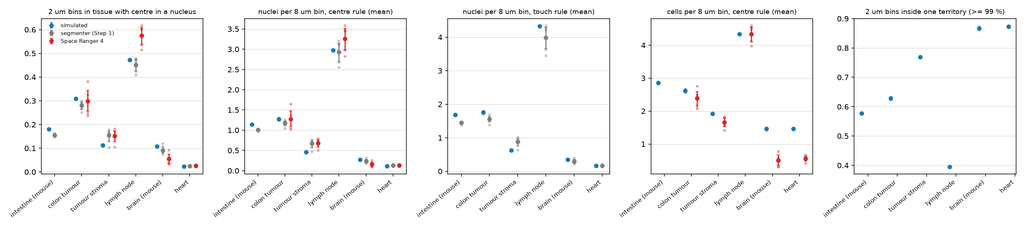

Descrittivi per tessuto. Ogni punto chiaro è un’area. Cosa guardare: con la regola del centro simulato e Space Ranger sono vicini nel tumore e nel linfonodo; le differenze di copertura nucleare seguono la densità dei preset (PH-2).

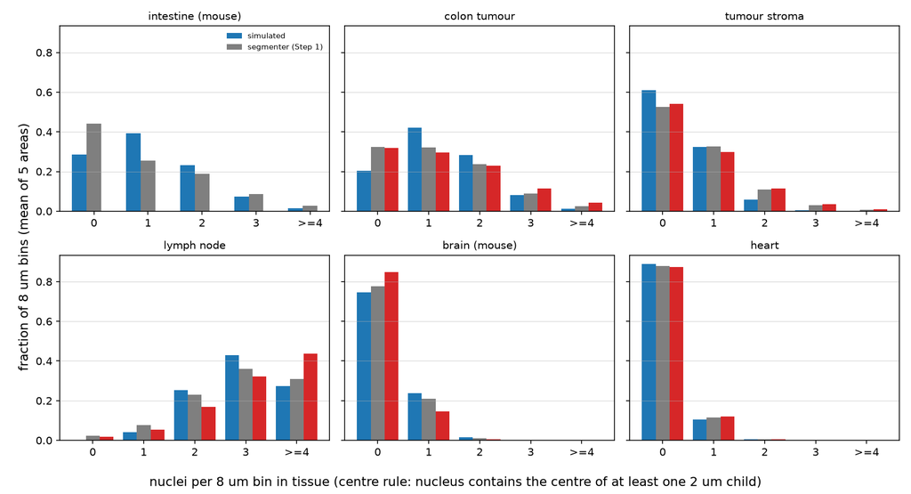

Distribuzione dei nuclei per blocco di 8 µm con la regola del centro, un pannello per tessuto.

PH-2 (post hoc). Correlazione fra rapporto di D-1 e rapporto della copertura nucleare sulle 30 aree: 1.000.

|  | tessuto | nuclei/mm² simulato | nuclei/mm² segmentatore | area nucleo simulato (µm²) | area nucleo segmentatore (µm²) | rapporto D-1 | rapporto densità | rapporto area |
| --- | --- | --- | --- | --- | --- | --- | --- | --- |
| A1 | intestino di topo | 12419 | 10582 | 14.5 | 14.6 | 1.164 | 1.174 | 0.992 |
| A2 | tumore del colon | 8924 | 7790 | 34.6 | 36.0 | 1.109 | 1.155 | 0.963 |
| A3 | stroma del tumore | 3100 | 4278 | 36.2 | 35.9 | 0.755 | 0.743 | 1.011 |
| A4 | linfonodo | 28096 | 27890 | 16.8 | 16.3 | 1.051 | 1.019 | 1.035 |
| A5 | cervello di topo | 1185 | 1044 | 90.8 | 91.3 | 1.209 | 1.243 | 1.015 |
| A6 | cuore | 988 | 1062 | 24.3 | 24.3 | 0.974 | 0.968 | 1.034 |

D-4: tempo e memoria di build_hd_grid() per area di 1 mm² (server condiviso, 5 processi; non per un manoscritto).

| tessuto | cellule | tempo mediano (s) | tempo max (s) | picco residente max (MB) | quota di vetro |
| --- | --- | --- | --- | --- | --- |
| intestino di topo | 8981 | 52.3 | 58.5 | 1169 | 0.70 |
| tumore del colon | 7689 | 55.7 | 62.2 | 1314 | 0.65 |
| stroma del tumore | 3089 | 53.9 | 54.2 | 1209 | 0.59 |
| linfonodo | 28015 | 77.1 | 79.5 | 1507 | 0.59 |
| cervello di topo | 925 | 59.9 | 81.3 | 1071 | 0.66 |
| cuore | 912 | 58.2 | 66.4 | 1201 | 0.61 |

# Revisione avversariale

Tre revisori indipendenti, con codice proprio (Python con shapely, R solo per leggere i file), sul commit `2808c44`:

- **Geometria** (sei aree, una per tessuto): griglia ricostruita dalla convenzione identica a quella salvata; stesse coppie (quadratino, cellula); scarto massimo per coppia 2.29e-6 µm² (territorio) e 1.79e-6 (nucleo), 0.24 della tolleranza della correzione 3; area di tessuto, `in_tissue`, somma a 8 µm identici; descrittivi simulati identici a 5e-15; fallimento di G-2 (c) riprodotto e spiegato al 100 % dalle regioni senza cellule.
- **Space Ranger** (cinque aree e la sezione del tumore): accordo 1 e 0 quadratini a metà con la griglia giusta, stessi insiemi di quadratini; griglie sbagliate come in tabella, salvo 1-2 coppie con lo spostamento di mezzo quadratino (pareggi a frazione 0.5, accordo 0.531932 contro 0.531944 nel tumore r1); numero di coppie diverso di 0-8 schegge sotto 1e-6 µm², che dipendono dalla precisione dell’arrotondamento; passo, blocchi e scarto dell’affine identici; descrittivi veri identici in 23 colonne. Discrepanza di definizione: D-2 simulato per tocco contro Space Ranger per centro (il tocco gonfia il conteggio di 1.3-1.5 volte). **Corretta**: confronto con Space Ranger alla regola del centro.
- **Codice**: nessun difetto nella griglia e nella verità geometrica (indici, centri, tessere, origine, territori di più poligoni, nuclei vuoti, regioni con buco). 19 rilievi, tutti chiusi: discrepanze di definizione (corrette), testo diverso dal codice (corretto), test senza potere (rafforzati: id di cellula non consecutivi, frazioni di tessuto 0.475 e 0.525, tessere di 50 µm, spostamento asimmetrico; mutanti M5 spostato, M9-M11 aggiunti; l’origine globale non è rilevabile a 1e4 µm per costruzione e BL-104 si chiude con la misura), casi limite silenziosi (ora errore o avviso), memoria misurata come picco del processo, G-3 rifatto completo.

Cartelle dei revisori: `/mnt/micron/geo_spatialtrans/S2.1/review/G5ac` (geometria), `review/g5bc` (Space Ranger), `review/` codice (sonde `g5d_*`).

# Cosa è girato

- Commit: vedi `git log` del ramo `step2-visium-grid` (messaggio «S2.1: chiusura» e precedenti); codice `R/05b1_build_hd_grid.R`, `R/testing/test_S2.1.R`, `tools/S2.1_*`.
- Nessun seme nella griglia (deterministica); bootstrap con seme 20261105, B = 2000.
- Pannello: 30 livelli U6 di S1.6, 5 processi (run1) e 3 processi (run2); controprova e descrittivi veri in un processo. Durata del calcolo finale circa 2 ore compresa la riproduzione.
- md5 dei 173 file letti prima e dopo in `/mnt/micron/geo_spatialtrans/S2.1/md5_{before,after}{,_extra}.txt`.
- Perimetro:

Scelte di Luca all’apertura (2026-11-05, in chat): «Griglia + controllo su Space Ranger + confronto descrittivo (Recommended)»; sulla revisione del documento di progetto: «cosa devo mandare a Daniele? Intanto procedi», poi «bypassiamo daniele, le decisioni vanno tutte bene il report è troppo tecnico per lui» (da registrare come decisione alla chiusura).

Lo step produce:

1. `build_hd_grid()` nel pacchetto (`R/05b1_build_hd_grid.R`, numerazione parallela a `04b*` dello Step 1: `05b*` sostituisce `R/05_grid_sampling.R`), con le funzioni piccole che la compongono: geometria della griglia, area di tessuto per quadratino, `truth$overlap` per tessere in coordinate locali, somma a 8 µm (`sum_to_8um()`, che serve anche agli step successivi per i conteggi);
2. la batteria di test `R/testing/test_S2.1.R` (PASS/FAIL per asserzione) e i mutanti;
3. la griglia e la verità geometrica sulle 30 aree simulate dello Step 1 (5 per tessuto, predefinito dei preset, file `U6` di S1.6) con gli invarianti;
4. la controprova sui vetrini veri contro Space Ranger 4 (4 sezioni, 25 aree: tutti i tessuti tranne l’intestino, che ha Space Ranger 3.0.0 senza segmentazione);
5. un confronto descrittivo, senza previsione, simulato contro vero alla scala dei quadratini.

Fuori perimetro, dichiarato: profili, trascritti, spostamento, strisce (step successivi); area di cattura intera (si misura il tempo per area di 1 mm², il bilancio dell’area intera resta allo step dell’orchestratore); nessun dato nuovo scaricato; nessun cambiamento al codice dello Step 1.

### Cosa calcola `build_hd_grid()`

- **Ingresso**: un `cell_layer` dello Step 1 (`place_cells()`). La scala è `metadata$pixel_size_um`, senza default: se manca, errore (decisione 10 del design dello Step 1; chiude BL-005). Le cellule sono quelle piazzate dallo Step 1, tutte, senza sotto-campionatura (chiude BL-010).
- **Griglia** (design sezione 3, DEC-038 punto 8): quadrati di 2 µm senza spazi; i = riga (asse y), j = colonna (asse x), da 0. Origine x₀ = xmin − m, y₀ = ymin − m, con (xmin, ymin) l’angolo del riquadro di territori e regioni e m = 280 µm (multiplo di 8; un margine che non è multiplo di 8 è un errore). Numero di righe e di colonne arrotondato per eccesso a un multiplo di 4, così ogni quadratino di 8 µm ha i suoi 16 figli. Centro del quadratino (i, j): (x₀ + 2 j + 1, y₀ + 2 i + 1).
- **Tessuto per quadratino**: area del quadratino coperta dall’unione delle regioni (somma sulle regioni, che non si sovrappongono), `tissue_frac` = area / 4 µm², `in_tissue` = `tissue_frac` ≥ 0.5 (design sezione 1).
- **`truth$overlap`**: una riga per coppia (quadratino, cellula) con area > 0: `area_territory_um2`, `area_nucleus_um2`, e le frazioni (area / 4 µm²). Calcolo con `overlay_prec()` dello Step 1 (arrotondamento a 1e-6 µm, mai `sf::st_intersection` sui territori, D2-12), per tessere di 500 µm con l’origine locale della tessera (BL-104); ogni quadratino appartiene a una sola tessera.
- **8 µm**: blocco (⌊i/4⌋, ⌊j/4⌋); `sum_to_8um()` somma i 16 figli (matrici sparse di conteggi, aree della verità geometrica).

# Appendice

## Da dove vengono i numeri del riassunto

[output not shown]